# Testing ensembles

Let’s see if using an ensemble of classifiers helps us results. As usual, we will take DTI as our benchmark. Let’s do some baseline classification first:

```r
source('~/ncr_notebooks/baseline_prediction/src/aux_functions.R')
tract_data = read.csv('~/data/baseline_prediction/stripped/dti.csv')
rm_me = (tract_data$fa_avg < .4 | tract_data$ad_avg < 1.18 | tract_data$rd_avg > .65 | tract_data$rd_avg < .5 |
         tract_data$norm.trans > .45 | tract_data$norm.rot > .008 | tract_data$goodSlices < 45 | tract_data$goodSlices > 70)
print(sprintf('Reducing from %d to %d scans', nrow(tract_data), nrow(tract_data)-sum(rm_me)))
```

```
[1] "Reducing from 727 to 656 scans"
```

```r
tract_data = tract_data[!rm_me, ]
gf_fname = '~/data/baseline_prediction/stripped/clinical.csv'
gf = read.csv(gf_fname)
gf = gf[gf$BASELINE=='BASELINE', ]
my_ids = intersect(gf$MRN, tract_data$MRN)
merged = mergeOnClosestDate(gf, tract_data, my_ids)
rm_me = abs(merged$dateX.minus.dateY.months) > 12
print(sprintf('Reducing from %d to %d scans', nrow(merged), nrow(merged)-sum(rm_me)))
```

```
[1] "Reducing from 289 to 200 scans"
```

```r
merged = merged[!rm_me, ]
phen_vars = c(which(grepl("^FA_", colnames(merged))),
              which(grepl("^AD_", colnames(merged))),
              which(grepl("^RD_", colnames(merged))),
              which(grepl("^MO_", colnames(merged)))
              )
X = merged[, phen_vars]
y = merged$DX_BASELINE
y[y != 'NV'] = 'ADHD'
y = factor(y)
rm_me = rowSums(is.na(X)) > 0
X = X[!rm_me, ]
merged = merged[!rm_me, ]
y = y[!rm_me]
get_needed_residuals = function(y, fm_str, cutoff) {
  fm = as.formula(fm_str)
  if (class(y) != 'factor') {
    fit = lm(fm)
    # selecting which covariates to use
    fm = "y ~ "
    for (r in 2:dim(summary(fit)$coefficients)[1]) {
      if (summary(fit)$coefficients[r, 4] < cutoff) {
        cname = rownames(summary(fit)$coefficients)[r]
        cname = gsub("SEXMale", "SEX", cname)
        fm = sprintf('%s + %s', fm, cname)
      }
    }
    # don't do anything if no variables were significant
    if (fm != 'y ~ ') {
      idx = !is.na(y)
      opt_fit = lm(as.formula(fm))
      y[idx] = opt_fit$residuals
    }
  }
  return(y)
}
X_resid = sapply(X, get_needed_residuals, 'y ~ merged$age + I(merged$age^2) + merged$SEX', .1)
X_resid = as.data.frame(X_resid)
```

```r
library(pROC)
myseed = 1234
cpuDiff = 1
tuneLength = 10
default_preproc = c("center", 'scale')
set.seed(myseed)
split <- createDataPartition(y, p = .8, list = FALSE)
Xtrain <- X_resid[ split, ]
ytrain <- y[ split ]
Xtest  <- X_resid[-split, ]
ytest = y[-split]
set.seed(myseed)
index <- createMultiFolds(ytrain, k = 5, times = 5)
library(doMC)
ncpus <- detectBatchCPUs()
njobs <- ncpus - cpuDiff
registerDoMC(njobs)
selFunc = 'best'  # maybe try oneSE and tolerance as well?
set.seed(myseed)
fullCtrl <- trainControl(method = "repeatedcv",
                         index = index,
                         search='grid',
                         summaryFunction = twoClassSummary,
                         classProbs = TRUE)
rndForestGrid <- expand.grid(.mtry=c(1:sqrt(ncol(Xtrain))))
rfFull <- train(Xtrain, ytrain,
                method = "rf",
                trControl = fullCtrl,
                tuneGrid=rndForestGrid,
                metric = 'ROC',
                preProcess = default_preproc)

getTrainPerf(rfFull)
```

| TrainROC | TrainSens | TrainSpec | method |
| --- | --- | --- | --- |
| 0.5821746 | 0.6108824 | 0.4778333 | rf |

```r
pred = predict(rfFull, Xtest)
postResample(pred, ytest)
```

```
 Accuracy     Kappa
0.6410256 0.2777778
```

```r
roc(as.numeric(ytest), as.numeric(pred))
```

```
Call:
roc.default(response = as.numeric(ytest), predictor = as.numeric(pred))

Data: as.numeric(pred) in 20 controls (as.numeric(ytest) 1) < 19 cases (as.numeric(ytest) 2).
Area under the curve: 0.6382
```

And I think we can improve even a bit more by using only univariate related variables:

```r
Xtrain <- X_resid[ split, ]
ytrain <- y[ split ]
Xtest  <- X_resid[-split, ]
ytest = y[-split]
# now we can remove correlated and non-informative variables
nzv = nearZeroVar(Xtrain)
print(nzv)
```

```
integer(0)
```

```r
if (length(nzv) > 0) {
  Xtrain = Xtrain[, -nzv]
}
correlations = cor(Xtrain, use='na.or.complete')
# library(corrplot)
# corrplot(correlations, order = "hclust")
highCorr = findCorrelation(correlations, cutoff=.75)
print(length(highCorr))
```

```
[1] 10
```

```r
if (length(highCorr) > 0) {
  Xtrain = Xtrain[, -highCorr]
}
# only evaluate variables with p-value < .05
pvals = sapply(Xtrain, function(d) t.test(d ~ ytrain)$p.value)
Xtrain = Xtrain[pvals <= .05]
print(dim(Xtrain))
```

```
[1] 159   6
```

```r
keep_me = sapply(colnames(Xtrain), function(d) which(colnames(Xtest) == d))
Xtest = Xtest[, keep_me]
rfFull <- train(Xtrain, ytrain,
                method = "rf",
                trControl = fullCtrl,
                tuneGrid=rndForestGrid,
                metric = 'ROC',
                preProcess = default_preproc)

getTrainPerf(rfFull)
```

| TrainROC | TrainSens | TrainSpec | method |
| --- | --- | --- | --- |
| 0.6385778 | 0.6354412 | 0.5743333 | rf |

```r
pred = predict(rfFull, Xtest)
postResample(pred, ytest)
```

```
 Accuracy     Kappa
0.6153846 0.2251656
```

```r
roc(as.numeric(ytest), as.numeric(pred))
```

```
Call:
roc.default(response = as.numeric(ytest), predictor = as.numeric(pred))

Data: as.numeric(pred) in 20 controls (as.numeric(ytest) 1) < 19 cases (as.numeric(ytest) 2).
Area under the curve: 0.6118
```

Not really… oh well. Can we do better if we use an ensemble of classifiers?

```r
Xtrain <- X_resid[ split, ]
ytrain <- y[ split ]
Xtest  <- X_resid[-split, ]
ytest = y[-split]
set.seed(myseed)
index <- createResample(ytrain, 25)
my_control <- trainControl(
  method="boot",
  number=25,
  savePredictions="final",
  classProbs=TRUE,
  index=index,
  summaryFunction=defaultSummary
  )
library("rpart")
library("caretEnsemble")
model_list <- caretList(
  Xtrain, ytrain,
  tuneLength=10,
  trControl=my_control,
  methodList=c('lda', 'rpart', 'glm', 'knn', 'svmRadial')
  )
```

[output not shown]

```r
results <- resamples(model_list)
summary(results)
```

```
Call:
summary.resamples(object = results)

Models: lda, rpart, glm, knn, svmRadial
Number of resamples: 25

Accuracy
            Min. 1st Qu. Median   Mean 3rd Qu.   Max. NA's
lda       0.4167  0.5273 0.5714 0.5654  0.6000 0.7037    0
rpart     0.4062  0.4754 0.5224 0.5249  0.5789 0.6379    0
glm       0.4333  0.5455 0.5614 0.5602  0.5741 0.6667    0
knn       0.3559  0.5000 0.5263 0.5177  0.5536 0.6296    0
svmRadial 0.3966  0.5088 0.5645 0.5507  0.5862 0.6667    0

Kappa
              Min.   1st Qu.  Median    Mean 3rd Qu.   Max. NA's
lda       -0.14380  0.050460 0.14480 0.13500 0.20790 0.4074    0
rpart     -0.16560 -0.037660 0.04200 0.05863 0.14290 0.2810    0
glm       -0.08974  0.093260 0.12200 0.12760 0.15050 0.3163    0
knn       -0.15330 -0.001151 0.04469 0.04366 0.09524 0.2603    0
svmRadial -0.19830  0.026180 0.08123 0.09711 0.19350 0.3288    0
```

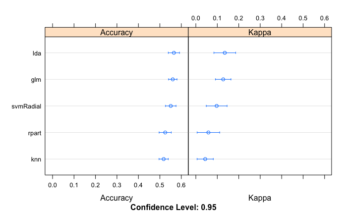

```r
dotplot(results)
```

```r
modelCor(results)
```

```
                  lda       rpart        glm        knn  svmRadial
lda        1.00000000 -0.08083031  0.5793431 0.13585965  0.1426324
rpart     -0.08083031  1.00000000 -0.1457996 0.07888921 -0.1629630
glm        0.57934310 -0.14579955  1.0000000 0.16787096  0.3696952
knn        0.13585965  0.07888921  0.1678710 1.00000000  0.2931470
svmRadial  0.14263242 -0.16296305  0.3696952 0.29314700  1.0000000
```

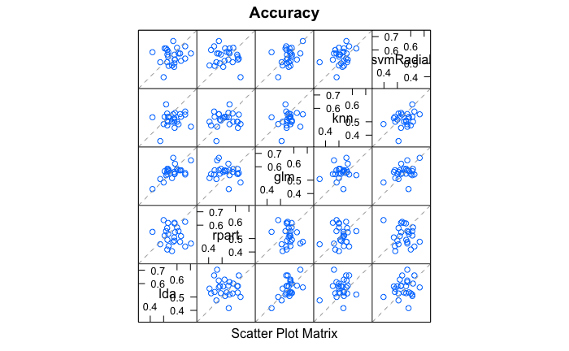

```r
splom(results)
```

```r
greedy_ensemble <- caretEnsemble(
  model_list,
  metric="Accuracy",
  trControl=trainControl(
    number=2,
    summaryFunction=defaultSummary,
    classProbs=TRUE
    ))
summary(greedy_ensemble)
```

```
The following models were ensembled: lda, rpart, glm, knn, svmRadial
They were weighted:
-0.4586 0.2087 -0.0799 0.2803 -1.5861 1.7608
The resulting Accuracy is: 0.602
The fit for each individual model on the Accuracy is:
    method  Accuracy AccuracySD
       lda 0.5653594 0.06349905
     rpart 0.5248635 0.06845990
       glm 0.5601926 0.04739307
       knn 0.5176535 0.05214756
 svmRadial 0.5507465 0.05956535
```

Thsi seems to have worked better than each individual model on its own. How does it look in the test set?

```r
library("caTools")
model_preds <- lapply(model_list, predict, newdata=Xtest, type="prob")
model_preds <- lapply(model_preds, function(x) x[,"ADHD"])
model_preds <- data.frame(model_preds)
ens_preds <- predict(greedy_ensemble, newdata=Xtest, type="prob")
model_preds$ensemble <- ens_preds
caTools::colAUC(model_preds, ytest)
```

```
             lda     rpart       glm       knn svmRadial  ensemble
ADHD vs. NV 0.65 0.5828947 0.6157895 0.6644737 0.7236842 0.6631579
```

svmRadial actually does better… that’s AUC though.

What if we combine them differently?

```r
glm_ensemble <- caretStack(
  model_list,
  method="glm",
  metric="Accuracy",
  trControl=trainControl(
    method="boot",
    number=10,
    savePredictions="final",
    classProbs=TRUE,
    summaryFunction=defaultSummary
  )
)
model_preds2 <- model_preds
model_preds2$ensemble <- predict(glm_ensemble, newdata=Xtest, type="prob")
CF <- coef(glm_ensemble$ens_model$finalModel)[-1]
colAUC(model_preds2, ytest)
```

```
             lda     rpart       glm       knn svmRadial  ensemble
ADHD vs. NV 0.65 0.5828947 0.6157895 0.6644737 0.7236842 0.6631579
```

```r
CF/sum(CF)
```

```
       lda      rpart        glm        knn  svmRadial
 0.3574579 -0.1369030  0.4802118 -2.7169253  3.0161586
```

Not really an improvement. What if we combine them using gbm instead?

```r
library("gbm")
gbm_ensemble <- caretStack(
  model_list,
  method="gbm",
  verbose=FALSE,
  tuneLength=10,
  metric="Accuracy",
  trControl=trainControl(
    method="boot",
    number=10,
    savePredictions="final",
    classProbs=TRUE,
    summaryFunction=defaultSummary
  )
)
model_preds3 <- model_preds
model_preds3$ensemble <- predict(gbm_ensemble, newdata=Xtest, type="prob")
colAUC(model_preds3, ytest)
```

```
             lda     rpart       glm       knn svmRadial  ensemble
ADHD vs. NV 0.65 0.5828947 0.6157895 0.6644737 0.7236842 0.7526316
```

OK, now we’re talking. We’re finally getting some improvement by combining classifiers.

The code is working, so let’s fine tune it!

First, a few questions:

- should we tune on accuracy or ROC?
- should we use all these classifiers? Add more?
- use bootstrapping is better than K-fold?
- should we clean the data?
- should we downsize the set to only univariate good variables?
- if a classifier sucks, does it automatically get bad weights, or should we go ahead and remove it?

# ROC or Accuracy?

```r
table(y)
```

```
y
ADHD   NV
 103   95
```

The split is quite even, so I wouldn’t worry too much about that. Let’s see if we get an improvement using ROC as well:

```r
mymetric='ROC'
smFunc = twoClassSummary
my_control <- trainControl(
  method="boot",
  number=25,
  savePredictions="final",
  classProbs=TRUE,
  index=index,
  summaryFunction=smFunc
  )
library("rpart")
library("caretEnsemble")
model_list <- caretList(
  Xtrain, ytrain,
  tuneLength=10,
  trControl=my_control,
  metric = mymetric,
  methodList=c('lda', 'rpart', 'glm', 'knn', 'svmRadial')
  )
```

[output not shown]

```r
greedy_ensemble <- caretEnsemble(
  model_list,
  metric=mymetric,
  trControl=trainControl(
    number=2,
    summaryFunction=smFunc,
    classProbs=TRUE
    ))
```

```r
summary(greedy_ensemble)
```

```
The following models were ensembled: lda, rpart, glm, knn, svmRadial
They were weighted:
-0.7404 0.2062 -0.1104 0.2545 -0.3995 1.3651
The resulting ROC is: 0.5956
The fit for each individual model on the ROC is:
    method       ROC      ROCSD
       lda 0.5781109 0.04823238
     rpart 0.5321066 0.07658592
       glm 0.5686285 0.04718717
       knn 0.5260202 0.06893715
 svmRadial 0.5927346 0.04542529
```

```r
model_preds <- lapply(model_list, predict, newdata=Xtest, type="prob")
model_preds <- lapply(model_preds, function(x) x[,"ADHD"])
model_preds <- data.frame(model_preds)
ens_preds <- predict(greedy_ensemble, newdata=Xtest, type="prob")
model_preds$ensemble <- ens_preds
caTools::colAUC(model_preds, ytest)
```

```
             lda     rpart       glm       knn svmRadial  ensemble
ADHD vs. NV 0.65 0.5828947 0.6157895 0.5776316 0.7315789 0.5184211
```

This is very poor. The ensemble is actually much worse than each model individually, especially in the test set. Let’s test this on accuracy:

```r
mymetric='Accuracy'
smFunc = defaultSummary
my_control <- trainControl(
  method="boot",
  number=25,
  savePredictions="final",
  classProbs=TRUE,
  index=index,
  summaryFunction=smFunc
  )
model_list <- caretList(
  Xtrain, ytrain,
  tuneLength=10,
  trControl=my_control,
  metric = mymetric,
  methodList=c('lda', 'rpart', 'glm', 'knn', 'svmRadial')
  )
```

[output not shown]

```r
greedy_ensemble <- caretEnsemble(
  model_list,
  metric=mymetric,
  trControl=trainControl(
    number=2,
    summaryFunction=smFunc,
    classProbs=TRUE
    ))
```

```r
summary(greedy_ensemble)
```

```
The following models were ensembled: lda, rpart, glm, knn, svmRadial
They were weighted:
-0.4459 0.209 -0.09 0.2939 -1.5818 1.7354
The resulting Accuracy is: 0.5952
The fit for each individual model on the Accuracy is:
    method  Accuracy AccuracySD
       lda 0.5653594 0.06349905
     rpart 0.5248635 0.06845990
       glm 0.5601926 0.04739307
       knn 0.5226517 0.05689752
 svmRadial 0.5494345 0.06067840
```

```r
model_preds <- lapply(model_list, predict, newdata=Xtest)
model_preds <- lapply(model_preds, function(x) postResample(x, ytest)[1])
model_preds <- data.frame(model_preds)
ens_preds <- predict(greedy_ensemble, newdata=Xtest)
model_preds$ensemble <- postResample(ens_preds, ytest)[1]
print(model_preds)
```

|  | lda | rpart | glm | knn | svmRadial | ensemble |
| --- | --- | --- | --- | --- | --- | --- |
| Accuracy | 0.4102564 | 0.5897436 | 0.4102564 | 0.5897436 | 0.7435897 | 0.3589744 |

Same here. But even though the accuracy is indeed better by combining the classifiers in the training set, it doesn’t generalize well in test. Is it just a matter of how we’re combining them?

```r
mymetric='ROC'
smFunc = twoClassSummary
my_control <- trainControl(
  method="boot",
  number=25,
  savePredictions="final",
  classProbs=TRUE,
  index=index,
  summaryFunction=smFunc
  )
library("rpart")
library("caretEnsemble")
model_list <- caretList(
  Xtrain, ytrain,
  tuneLength=10,
  trControl=my_control,
  metric = mymetric,
  methodList=c('lda', 'rpart', 'glm', 'knn', 'svmRadial')
  )
```

[output not shown]

```r
greedy_ensemble <- caretEnsemble(
  model_list,
  metric=mymetric,
  trControl=trainControl(
    number=2,
    summaryFunction=smFunc,
    classProbs=TRUE
    ))
glm_ensemble <- caretStack(
  model_list,
  method="glm",
  metric=mymetric,
  trControl=trainControl(
    method="boot",
    number=10,
    savePredictions="final",
    classProbs=TRUE,
    summaryFunction=smFunc
  )
)
gbm_ensemble <- caretStack(
  model_list,
  method="gbm",
  verbose=FALSE,
  tuneLength=10,
  metric=mymetric,
  trControl=trainControl(
    method="boot",
    number=10,
    savePredictions="final",
    classProbs=TRUE,
    summaryFunction=smFunc
  )
)
summary(greedy_ensemble)
```

```
The following models were ensembled: lda, rpart, glm, knn, svmRadial
They were weighted:
-0.7618 0.2076 -0.1057 0.2548 -0.376 1.3816
The resulting ROC is: 0.5979
The fit for each individual model on the ROC is:
    method       ROC      ROCSD
       lda 0.5781109 0.04823238
     rpart 0.5321066 0.07658592
       glm 0.5686285 0.04718717
       knn 0.5260202 0.06893715
 svmRadial 0.5931833 0.04512903
```

```r
summary(glm_ensemble)
```

```
Call:
NULL

Deviance Residuals:
    Min       1Q   Median       3Q      Max
-1.5489  -1.1301  -0.8877   1.1511   1.5616

Coefficients:
            Estimate Std. Error z value Pr(>|z|)
(Intercept)  -0.7618     0.1527  -4.988 6.11e-07 ***
lda           0.2076     0.2134   0.973    0.330
rpart        -0.1057     0.1881  -0.562    0.574
glm           0.2548     0.1782   1.430    0.153
knn          -0.3760     0.2352  -1.599    0.110
svmRadial     1.3816     0.3142   4.397 1.10e-05 ***
---
Signif. codes:  0 ‘***’ 0.001 ‘**’ 0.01 ‘*’ 0.05 ‘.’ 0.1 ‘ ’ 1

(Dispersion parameter for binomial family taken to be 1)

    Null deviance: 2008.0  on 1448  degrees of freedom
Residual deviance: 1963.6  on 1443  degrees of freedom
AIC: 1975.6

Number of Fisher Scoring iterations: 4
```

|  | var | rel.inf |
| --- | --- | --- |
| svmRadial | svmRadial | 39.774278 |
| lda | lda | 30.539836 |
| rpart | rpart | 20.996622 |
| glm | glm | 5.725819 |
| knn | knn | 2.963444 |

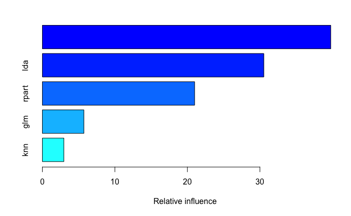

```r
summary(gbm_ensemble)
```

```r
model_preds <- lapply(model_list, predict, newdata=Xtest, type="prob")
model_preds <- lapply(model_preds, function(x) x[,"ADHD"])
model_preds <- data.frame(model_preds)
ens_preds <- predict(greedy_ensemble, newdata=Xtest, type="prob")
model_preds$greedyE <- ens_preds
ens_preds <- predict(glm_ensemble, newdata=Xtest, type="prob")
model_preds$glmE <- ens_preds
ens_preds <- predict(gbm_ensemble, newdata=Xtest, type="prob")
model_preds$gbmE <- ens_preds
caTools::colAUC(model_preds, ytest)
```

```
             lda     rpart       glm       knn svmRadial   greedyE      glmE      gbmE
ADHD vs. NV 0.65 0.5828947 0.6157895 0.5776316 0.7368421 0.5210526 0.5210526 0.5394737
```

OK, so no much improvement regardless of how we ensemble the models, if using AUC. How about accuracy?

```r
mymetric='Accuracy'
smFunc = defaultSummary
my_control <- trainControl(
  method="boot",
  number=25,
  savePredictions="final",
  classProbs=TRUE,
  index=index,
  summaryFunction=smFunc
  )
model_list <- caretList(
  Xtrain, ytrain,
  tuneLength=10,
  trControl=my_control,
  metric = mymetric,
  methodList=c('lda', 'rpart', 'glm', 'knn', 'svmRadial')
  )
```

[output not shown]

```r
greedy_ensemble <- caretEnsemble(
  model_list,
  metric=mymetric,
  trControl=trainControl(
    number=2,
    summaryFunction=smFunc,
    classProbs=TRUE
    ))
glm_ensemble <- caretStack(
  model_list,
  method="glm",
  metric=mymetric,
  trControl=trainControl(
    method="boot",
    number=10,
    savePredictions="final",
    classProbs=TRUE,
    summaryFunction=smFunc
  )
)
gbm_ensemble <- caretStack(
  model_list,
  method="gbm",
  verbose=FALSE,
  tuneLength=10,
  metric=mymetric,
  trControl=trainControl(
    method="boot",
    number=10,
    savePredictions="final",
    classProbs=TRUE,
    summaryFunction=smFunc
  )
)
summary(greedy_ensemble)
```

```
The following models were ensembled: lda, rpart, glm, knn, svmRadial
They were weighted:
-0.4878 0.2013 -0.0801 0.2989 -1.4768 1.755
The resulting Accuracy is: 0.5978
The fit for each individual model on the Accuracy is:
    method  Accuracy AccuracySD
       lda 0.5653594 0.06349905
     rpart 0.5248635 0.06845990
       glm 0.5601926 0.04739307
       knn 0.5181435 0.05374862
 svmRadial 0.5525044 0.05554565
```

```r
summary(glm_ensemble)
```

```
Call:
NULL

Deviance Residuals:
    Min       1Q   Median       3Q      Max
-1.6215  -1.1227  -0.8692   1.1550   1.6066

Coefficients:
            Estimate Std. Error z value Pr(>|z|)
(Intercept)  -0.4878     0.1717  -2.841 0.004495 **
lda           0.2013     0.2137   0.942 0.346145
rpart        -0.0801     0.1896  -0.422 0.672726
glm           0.2989     0.1788   1.672 0.094549 .
knn          -1.4768     0.4394  -3.361 0.000777 ***
svmRadial     1.7550     0.3467   5.062 4.14e-07 ***
---
Signif. codes:  0 ‘***’ 0.001 ‘**’ 0.01 ‘*’ 0.05 ‘.’ 0.1 ‘ ’ 1

(Dispersion parameter for binomial family taken to be 1)

    Null deviance: 2008.0  on 1448  degrees of freedom
Residual deviance: 1956.1  on 1443  degrees of freedom
AIC: 1968.1

Number of Fisher Scoring iterations: 4
```

|  | var | rel.inf |
| --- | --- | --- |
| svmRadial | svmRadial | 38.41043 |
| lda | lda | 26.24865 |
| knn | knn | 13.80789 |
| rpart | rpart | 11.62226 |
| glm | glm | 9.91077 |

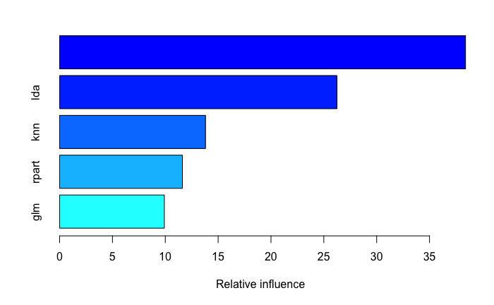

```r
summary(gbm_ensemble)
```

```r
model_preds <- lapply(model_list, predict, newdata=Xtest)
model_preds <- lapply(model_preds, function(x) postResample(x, ytest)[1])
model_preds <- data.frame(model_preds)
ens_preds <- predict(greedy_ensemble, newdata=Xtest)
model_preds$greedyE <- postResample(ens_preds, ytest)[1]
ens_preds <- predict(glm_ensemble, newdata=Xtest)
model_preds$glmE <- postResample(ens_preds, ytest)[1]
ens_preds <- predict(gbm_ensemble, newdata=Xtest)
model_preds$gbmE <- postResample(ens_preds, ytest)[1]
print(model_preds)
```

|  | lda | rpart | glm | knn | svmRadial | greedyE | glmE | gbmE |
| --- | --- | --- | --- | --- | --- | --- | --- | --- |
| Accuracy | 0.4102564 | 0.5897436 | 0.4102564 | 0.5897436 | 0.5897436 | 0.3846154 | 0.3846154 | 0.3846154 |

For now, the no information thresholding is 0.520202.

# Which classifiers to use?

Are all these classifiers performing well in the training set? Also, we should try others that we normally enjoy:

```r
mymetric='Accuracy'
smFunc = defaultSummary
Xtrain <- X_resid[ split, ]
ytrain <- y[ split ]
Xtest  <- X_resid[-split, ]
ytest = y[-split]
my_control <- trainControl(
  method="boot",
  number=25,
  savePredictions="final",
  classProbs=TRUE,
  index=index,
  summaryFunction=smFunc,
  preProc=c('YeoJohnson', 'center', 'scale')
  )
model_list <- caretList(
  Xtrain, ytrain,
  tuneLength=10,
  trControl=my_control,
  metric = mymetric,
  methodList=c('lda', 'rpart', 'glm', 'knn', 'svmRadial', 'LogitBoost', 'rf', 'xgbTree')
  )
```

[output not shown]

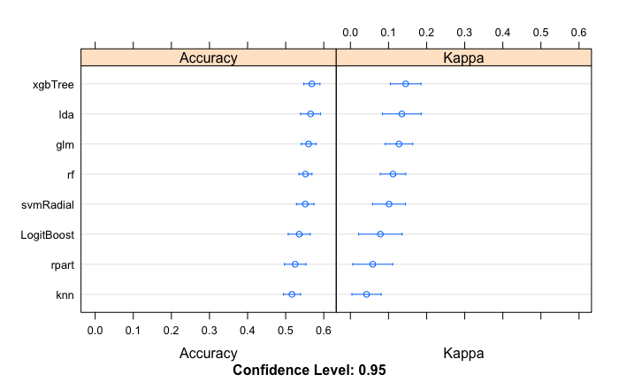

```r
results <- resamples(model_list)
dotplot(results)
```

```r
modelCor(results)
```

```
                   lda       rpart          glm        knn   svmRadial  LogitBoost        rf
lda         1.00000000 -0.08083031  0.579343101 0.16747156  0.03949855 0.060500332 0.1019131
rpart      -0.08083031  1.00000000 -0.145799550 0.07314713 -0.12958770 0.440778107 0.3255265
glm         0.57934310 -0.14579955  1.000000000 0.22459949  0.31859764 0.007531808 0.3713196
knn         0.16747156  0.07314713  0.224599494 1.00000000  0.22878181 0.211205833 0.1665673
svmRadial   0.03949855 -0.12958770  0.318597639 0.22878181  1.00000000 0.223533366 0.4105291
LogitBoost  0.06050033  0.44077811  0.007531808 0.21120583  0.22353337 1.000000000 0.1366821
rf          0.10191309  0.32552650  0.371319605 0.16656729  0.41052913 0.136682091 1.0000000
xgbTree    -0.27840029  0.31767923  0.062113664 0.06291348  0.33591162 0.241677790 0.2076122
               xgbTree
lda        -0.27840029
rpart       0.31767923
glm         0.06211366
knn         0.06291348
svmRadial   0.33591162
LogitBoost  0.24167779
rf          0.20761225
xgbTree     1.00000000
```

None of them is performing too well, but at least they’re not too correlated. Does it get a bit better if we clean up the variables?

```r
Xtrain <- X_resid[ split, ]
ytrain <- y[ split ]
Xtest  <- X_resid[-split, ]
ytest = y[-split]
# only evaluate variables with p-value < .05
pvals = sapply(Xtrain, function(d) t.test(d ~ ytrain)$p.value)
Xtrain = Xtrain[pvals <= .05]
print(dim(Xtrain))
```

```
[1] 159   7
```

```r
# now we can remove correlated and non-informative variables
nzv = nearZeroVar(Xtrain)
print(nzv)
```

```
integer(0)
```

```r
if (length(nzv) > 0) {
  Xtrain = Xtrain[, -nzv]
}
correlations = cor(Xtrain, use='na.or.complete')
# library(corrplot)
# corrplot(correlations, order = "hclust")
highCorr = findCorrelation(correlations, cutoff=.75)
print(length(highCorr))
```

```
[1] 0
```

```r
if (length(highCorr) > 0) {
  Xtrain = Xtrain[, -highCorr]
}
keep_me = sapply(colnames(Xtrain), function(d) which(colnames(Xtest) == d))
Xtest = Xtest[, keep_me]
```

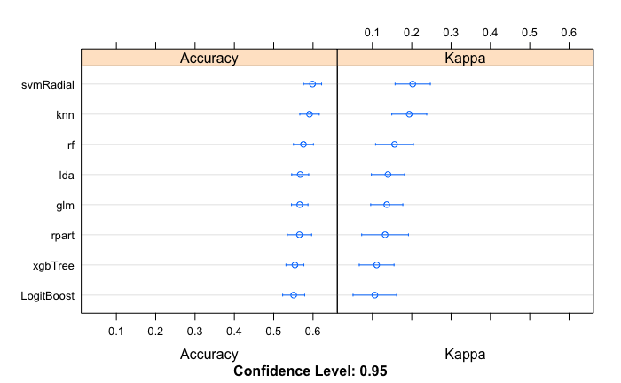

```r
mymetric='Accuracy'
smFunc = defaultSummary
my_control <- trainControl(
  method="boot",
  number=25,
  savePredictions="final",
  classProbs=TRUE,
  index=index,
  summaryFunction=smFunc,
  preProc=c('YeoJohnson', 'center', 'scale')
  )
model_list <- caretList(
  Xtrain, ytrain,
  tuneLength=10,
  trControl=my_control,
  metric = mymetric,
  methodList=c('lda', 'rpart', 'glm', 'knn', 'svmRadial', 'LogitBoost', 'rf', 'xgbTree')
  )
results <- resamples(model_list)
dotplot(results)
```

```r
modelCor(results)
```

```
                 lda     rpart       glm       knn svmRadial LogitBoost        rf   xgbTree
lda        1.0000000 0.2306144 0.9602082 0.6678124 0.6575445  0.3623392 0.4529972 0.3337350
rpart      0.2306144 1.0000000 0.1474848 0.5650943 0.4402354  0.5149997 0.6051250 0.5202945
glm        0.9602082 0.1474848 1.0000000 0.6104340 0.6628112  0.2744197 0.4212829 0.3127248
knn        0.6678124 0.5650943 0.6104340 1.0000000 0.6221298  0.4955525 0.4862776 0.3017342
svmRadial  0.6575445 0.4402354 0.6628112 0.6221298 1.0000000  0.3949539 0.6157913 0.5224949
LogitBoost 0.3623392 0.5149997 0.2744197 0.4955525 0.3949539  1.0000000 0.5397022 0.4415362
rf         0.4529972 0.6051250 0.4212829 0.4862776 0.6157913  0.5397022 1.0000000 0.5994941
xgbTree    0.3337350 0.5202945 0.3127248 0.3017342 0.5224949  0.4415362 0.5994941 1.0000000
```

It looks like there isn’t much difference whether we clean it up or not, but the models get a lot more correlated if we have fewer variables. Is that true if we use ROC as well?

```r
mymetric='ROC'
smFunc = twoClassSummary
Xtrain <- X_resid[ split, ]
ytrain <- y[ split ]
Xtest  <- X_resid[-split, ]
ytest = y[-split]
my_control <- trainControl(
  method="boot",
  number=25,
  savePredictions="final",
  classProbs=TRUE,
  index=index,
  summaryFunction=smFunc,
  preProc=c('YeoJohnson', 'center', 'scale')
  )
model_list <- caretList(
  Xtrain, ytrain,
  tuneLength=10,
  trControl=my_control,
  metric = mymetric,
  methodList=c('lda', 'rpart', 'glm', 'knn', 'svmRadial', 'LogitBoost', 'rf', 'xgbTree')
  )
```

[output not shown]

```r
results <- resamples(model_list)
summary(results)
```

```
Call:
summary.resamples(object = results)

Models: lda, rpart, glm, knn, svmRadial, LogitBoost, rf, xgbTree
Number of resamples: 25

ROC
             Min. 1st Qu. Median   Mean 3rd Qu.   Max. NA's
lda        0.4630  0.5568 0.5920 0.5781  0.6113 0.6497    0
rpart      0.3962  0.4910 0.5173 0.5321  0.5812 0.6718    0
glm        0.4641  0.5479 0.5657 0.5686  0.5945 0.6574    0
knn        0.4043  0.4804 0.5162 0.5260  0.5794 0.6416    0
svmRadial  0.5021  0.5591 0.6025 0.5937  0.6195 0.7150    0
LogitBoost 0.2905  0.5065 0.5598 0.5449  0.5901 0.6648    0
rf         0.4890  0.5447 0.5780 0.5744  0.6083 0.6720    0
xgbTree    0.5209  0.5833 0.6000 0.5981  0.6141 0.6824    0

Sens
             Min. 1st Qu. Median   Mean 3rd Qu.   Max. NA's
lda        0.3889  0.5556 0.6000 0.6177  0.6875 0.8966    0
rpart      0.2500  0.4643 0.5862 0.5698  0.6250 0.7879    0
glm        0.3611  0.5484 0.5926 0.6057  0.6429 0.8333    0
knn        0.3611  0.5938 0.6400 0.6395  0.6667 0.8519    0
svmRadial  0.2667  0.4667 0.5417 0.5475  0.6071 0.8108    0
LogitBoost 0.2857  0.4516 0.5333 0.5437  0.6429 0.7407    0
rf         0.4483  0.5714 0.6216 0.6347  0.7143 0.9167    0
xgbTree    0.4138  0.5152 0.6400 0.6060  0.6786 0.7576    0

Spec
             Min. 1st Qu. Median   Mean 3rd Qu.   Max. NA's
lda        0.4074  0.4444 0.5000 0.5190  0.5926 0.6897    0
rpart      0.2857  0.3846 0.4286 0.4895  0.6154 0.7778    0
glm        0.3333  0.4516 0.5385 0.5241  0.5769 0.7037    0
knn        0.2222  0.3000 0.3571 0.3869  0.4286 0.7308    0
svmRadial  0.2857  0.4750 0.5600 0.5506  0.6296 0.7308    0
LogitBoost 0.3793  0.4516 0.5161 0.5373  0.6296 0.7037    0
rf         0.3103  0.3448 0.4242 0.4600  0.5769 0.7083    0
xgbTree    0.3333  0.4250 0.5000 0.5047  0.5600 0.7308    0
```

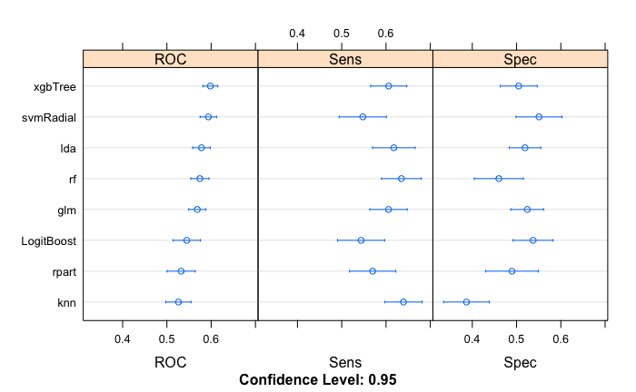

```r
dotplot(results)
```

```r
modelCor(results)
```

```
                   lda       rpart         glm         knn   svmRadial LogitBoost        rf
lda         1.00000000 -0.01312070  0.73755308 -0.15175648  0.25526558 0.04414815 0.3154803
rpart      -0.01312070  1.00000000  0.07676734  0.19783360  0.12123474 0.53566328 0.1728813
glm         0.73755308  0.07676734  1.00000000 -0.11194523  0.47303717 0.15155193 0.3386557
knn        -0.15175648  0.19783360 -0.11194523  1.00000000 -0.07719288 0.21097748 0.1684692
svmRadial   0.25526558  0.12123474  0.47303717 -0.07719288  1.00000000 0.24828557 0.6072617
LogitBoost  0.04414815  0.53566328  0.15155193  0.21097748  0.24828557 1.00000000 0.3249876
rf          0.31548035  0.17288129  0.33865570  0.16846921  0.60726168 0.32498758 1.0000000
xgbTree     0.04376310  0.10276824  0.14342424  0.07635408  0.04209519 0.06829525 0.3509841
              xgbTree
lda        0.04376310
rpart      0.10276824
glm        0.14342424
knn        0.07635408
svmRadial  0.04209519
LogitBoost 0.06829525
rf         0.35098405
xgbTree    1.00000000
```

```r
Xtrain <- X_resid[ split, ]
ytrain <- y[ split ]
Xtest  <- X_resid[-split, ]
ytest = y[-split]
# only evaluate variables with p-value < .05
pvals = sapply(Xtrain, function(d) t.test(d ~ ytrain)$p.value)
Xtrain = Xtrain[pvals <= .05]
print(dim(Xtrain))
```

```
[1] 159   7
```

```r
# now we can remove correlated and non-informative variables
nzv = nearZeroVar(Xtrain)
print(nzv)
```

```
integer(0)
```

```r
if (length(nzv) > 0) {
  Xtrain = Xtrain[, -nzv]
}
correlations = cor(Xtrain, use='na.or.complete')
# library(corrplot)
# corrplot(correlations, order = "hclust")
highCorr = findCorrelation(correlations, cutoff=.75)
print(length(highCorr))
```

```
[1] 0
```

```r
if (length(highCorr) > 0) {
  Xtrain = Xtrain[, -highCorr]
}
keep_me = sapply(colnames(Xtrain), function(d) which(colnames(Xtest) == d))
Xtest = Xtest[, keep_me]
mymetric='ROC'
smFunc = twoClassSummary
my_control <- trainControl(
  method="boot",
  number=25,
  savePredictions="final",
  classProbs=TRUE,
  index=index,
  summaryFunction=smFunc,
  preProc=c('YeoJohnson', 'center', 'scale')
  )
model_list <- caretList(
  Xtrain, ytrain,
  tuneLength=10,
  trControl=my_control,
  metric = mymetric,
  methodList=c('lda', 'rpart', 'glm', 'knn', 'svmRadial', 'LogitBoost', 'rf', 'xgbTree')
  )
results <- resamples(model_list)
summary(results)
```

```
Call:
summary.resamples(object = results)

Models: lda, rpart, glm, knn, svmRadial, LogitBoost, rf, xgbTree
Number of resamples: 25

ROC
             Min. 1st Qu. Median   Mean 3rd Qu.   Max. NA's
lda        0.5146  0.5679 0.6085 0.6031  0.6232 0.7305    0
rpart      0.4312  0.5119 0.5914 0.5718  0.6213 0.6687    0
glm        0.5146  0.5630 0.6036 0.6016  0.6203 0.7266    0
knn        0.5297  0.5774 0.6037 0.6186  0.6518 0.7582    0
svmRadial  0.5417  0.5959 0.6386 0.6389  0.6911 0.7294    0
LogitBoost 0.4855  0.5330 0.5632 0.5715  0.5855 0.7302    0
rf         0.4609  0.5806 0.6070 0.6071  0.6414 0.7486    0
xgbTree    0.4858  0.5400 0.5755 0.5757  0.6106 0.6774    0

Sens
             Min. 1st Qu. Median   Mean 3rd Qu.   Max. NA's
lda        0.4828  0.5517 0.6207 0.6335  0.7273 0.8000    0
rpart      0.3000  0.4643 0.6000 0.5980  0.7200 0.8966    0
glm        0.4242  0.5517 0.6207 0.6265  0.7083 0.8000    0
knn        0.3226  0.5172 0.6216 0.6298  0.7500 0.8929    0
svmRadial  0.4286  0.5000 0.6000 0.5982  0.6552 0.8182    0
LogitBoost 0.3214  0.5357 0.5938 0.5964  0.6333 0.8929    0
rf         0.3333  0.5517 0.6250 0.6198  0.7000 0.8750    0
xgbTree    0.4286  0.5172 0.5938 0.5966  0.6552 0.8333    0

Spec
             Min. 1st Qu. Median   Mean 3rd Qu.   Max. NA's
lda        0.2593  0.4194 0.5185 0.5091  0.5769 0.8077    0
rpart      0.2963  0.4444 0.5556 0.5355  0.6154 0.7692    0
glm        0.2593  0.4194 0.5143 0.5129  0.5769 0.8077    0
knn        0.2903  0.4839 0.5833 0.5703  0.6667 0.8077    0
svmRadial  0.3333  0.5185 0.6071 0.6054  0.7097 0.8462    0
LogitBoost 0.2800  0.4286 0.5161 0.5035  0.5833 0.6538    0
rf         0.3250  0.5000 0.5714 0.5477  0.6250 0.7308    0
xgbTree    0.3333  0.4483 0.5200 0.5176  0.5806 0.7692    0
```

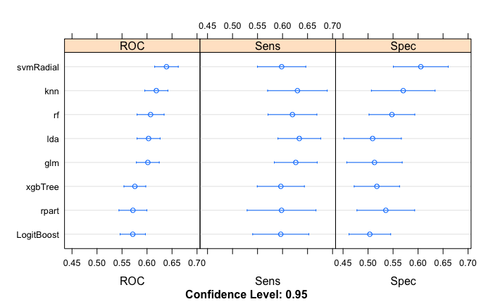

```r
dotplot(results)
```

```r
modelCor(results)
```

```
                 lda     rpart       glm       knn svmRadial LogitBoost        rf   xgbTree
lda        1.0000000 0.4528240 0.9966617 0.6416512 0.7291915  0.3156664 0.6024701 0.3761145
rpart      0.4528240 1.0000000 0.4365339 0.4306596 0.6635963  0.2606513 0.6626980 0.3158527
glm        0.9966617 0.4365339 1.0000000 0.6554541 0.7342591  0.3278524 0.6141983 0.3653417
knn        0.6416512 0.4306596 0.6554541 1.0000000 0.7464590  0.3613643 0.5946365 0.1557034
svmRadial  0.7291915 0.6635963 0.7342591 0.7464590 1.0000000  0.3056154 0.6816206 0.3515483
LogitBoost 0.3156664 0.2606513 0.3278524 0.3613643 0.3056154  1.0000000 0.4810012 0.4047128
rf         0.6024701 0.6626980 0.6141983 0.5946365 0.6816206  0.4810012 1.0000000 0.3476145
xgbTree    0.3761145 0.3158527 0.3653417 0.1557034 0.3515483  0.4047128 0.3476145 1.0000000
```

Yep, same thing here. Using the small set of variables just makes the models way more correlated.

But in the results with the entire set of variables, svmRadial, lda, and xgbTree stand out, so maybe we could combine them in different ways?

```r
gbm_ensemble <- caretStack(
  model_list,
  method="gbm",
  verbose=FALSE,
  tuneLength=10,
  metric=mymetric,
  trControl=trainControl(
    method="boot",
    number=50,
    savePredictions="final",
    classProbs=TRUE,
    summaryFunction=smFunc
  )
)
summary(greedy_ensemble)
```

[output not shown]

```r
summary(glm_ensemble)
```

[output not shown]

[output not shown]

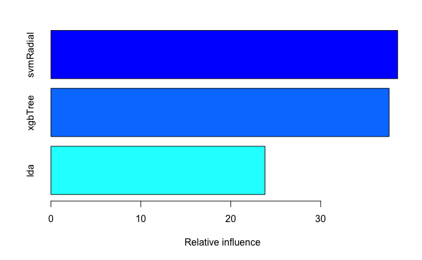

```r
summary(gbm_ensemble)
```

```r
model_preds <- lapply(model_list, predict, newdata=Xtest, type="prob")
model_preds <- lapply(model_preds, function(x) x[,"ADHD"])
model_preds <- data.frame(model_preds)
ens_preds <- predict(greedy_ensemble, newdata=Xtest, type="prob")
model_preds$greedyE <- ens_preds
ens_preds <- predict(glm_ensemble, newdata=Xtest, type="prob")
model_preds$glmE <- ens_preds
ens_preds <- predict(gbm_ensemble, newdata=Xtest, type="prob")
model_preds$gbmE <- ens_preds
caTools::colAUC(model_preds, ytest)
```

[output not shown]

Unfortunately, this is not working either… the combination doesn’t do better in terms of AUC then the individual classifiers. Should we take a look at accuracy?

```r
Xtrain <- X_resid[ split, ]
ytrain <- y[ split ]
Xtest  <- X_resid[-split, ]
ytest = y[-split]
mymetric='Accuracy'
smFunc = defaultSummary
my_control <- trainControl(
  method="boot",
  number=25,
  savePredictions="final",
  classProbs=TRUE,
  index=index,
  summaryFunction=smFunc,
  preProc=c('YeoJohnson', 'center', 'scale')
  )
model_list <- caretList(
  Xtrain, ytrain,
  tuneLength=10,
  trControl=my_control,
  metric = mymetric,
  methodList=c('lda', 'rpart', 'glm', 'knn', 'svmRadial', 'LogitBoost', 'rf', 'xgbTree')
  )
```

[output not shown]

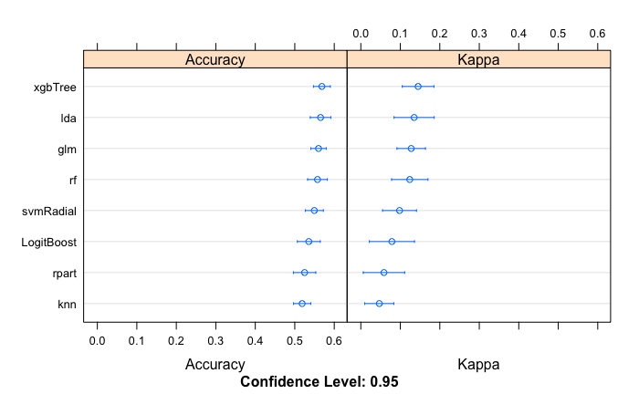

```r
results <- resamples(model_list)
dotplot(results)
```

```r
modelCor(results)
```

```
                   lda       rpart          glm         knn  svmRadial  LogitBoost         rf
lda         1.00000000 -0.08083031  0.579343101  0.25529265  0.1602474 0.060500332 0.07230955
rpart      -0.08083031  1.00000000 -0.145799550  0.08632297 -0.3168171 0.440778107 0.39606953
glm         0.57934310 -0.14579955  1.000000000  0.22895055  0.4409420 0.007531808 0.25551597
knn         0.25529265  0.08632297  0.228950550  1.00000000  0.1972109 0.244819236 0.31532642
svmRadial   0.16024737 -0.31681710  0.440942008  0.19721091  1.0000000 0.068573201 0.44609636
LogitBoost  0.06050033  0.44077811  0.007531808  0.24481924  0.0685732 1.000000000 0.41955049
rf          0.07230955  0.39606953  0.255515969  0.31532642  0.4460964 0.419550495 1.00000000
xgbTree    -0.27840029  0.31767923  0.062113664 -0.02902683  0.1125140 0.241677790 0.30144039
               xgbTree
lda        -0.27840029
rpart       0.31767923
glm         0.06211366
knn        -0.02902683
svmRadial   0.11251398
LogitBoost  0.24167779
rf          0.30144039
xgbTree     1.00000000
```

There are very similar models, but not necessarily highly correlated. And many that are simply at chance. So, let’s just pick the top 3 then: